# NumPy Arrays

We will study `NumPy` arrays in more detail.

```python
import numpy as np
```

## Arrays

It should have become amply clear by now that both vectors and matrices are `NumPy` arrays. Each array in `NumPy` has a dimension. Vectors are one-dimensional arrays while matrices are two-dimensional arrays. For example:

$$\mathbf{x} = \begin{bmatrix}
1\\
2\\
3
\end{bmatrix},
\mathbf{M} = \begin{bmatrix}
1 & 2\\
3 & 4\\
5 & 6
\end{bmatrix}$$

In `NumPy`:

```python
x = np.array([1, 2, 3])
M = np.array([
    [1, 2],
    [3, 4],
    [5, 6]
])
```

## Reshaping

Arrays can be reshaped. We will do a number of examples here.

### Example-1: Vector to matrix

We start with a vector:

$$\mathbf{x} = \begin{bmatrix}
1 & 2 & 3 & 4 & 5 & 6
\end{bmatrix}$$

We can reshape it into the following matrix:

$$\mathbf{M} = \begin{bmatrix}
1 & 2\\
3 & 4\\
5 & 6
\end{bmatrix}$$

In `NumPy`:

```python
x = np.array([1, 2, 3, 4, 5, 6])
x
```

```
array([1, 2, 3, 4, 5, 6])
```

```python
M = x.reshape(3, 2)
M
```

```
array([[1, 2],
       [3, 4],
       [5, 6]])
```

### Example-2: Matrix to vector

We now start with a matrix:

$$\mathbf{M} = \begin{bmatrix}
1 & 2 & 3\\
4 & 5 & 6
\end{bmatrix}$$

We can now reshape it into a vector:

$$\mathbf{x} = \begin{bmatrix}
1 & 2 & 3 & 4 & 5 & 6
\end{bmatrix}$$

In `NumPy`:

```python
M = np.array([
    [1, 2, 3],
    [4, 5, 6]
])
M
```

```
array([[1, 2, 3],
       [4, 5, 6]])
```

```python
x = M.reshape(6)
x
```

```
array([1, 2, 3, 4, 5, 6])
```

### Example-3: Matrix to matrix

We can reshape a matrix into another matrix as well. Sometimes, we may not want to specify the dimensions completely. In such cases, we can let `NumPy` figure them out by letting one of the dimensions to be $-1$. For example:

$$\mathbf{M} = \begin{bmatrix}
1 & 2 & 3\\
4 & 5 & 6
\end{bmatrix}$$

Let us say we want to reshape it in such a way that there are three rows:

$$\mathbf{P} = \begin{bmatrix}
1 & 2\\
3 & 4\\
5 & 6
\end{bmatrix}$$

In `NumPy`:

```python
M = np.array([
    [1, 2, 3],
    [4, 5, 6]
])
P = M.reshape(3, -1)
P
```

```
array([[1, 2],
       [3, 4],
       [5, 6]])
```

A useful function that mirrors the range function in Python:

```python
x = np.arange(1, 6)
x
```

```
array([1, 2, 3, 4, 5])
```

## Matrix-vector addition

Sometimes we would have to add a vector to each row or column of a matrix. There are two cases to consider. If the vector to be added is a:

- row vector
- column vector

### Row-vector

Consider the following matrix $\mathbf{M}$ and vector $\mathbf{b}$:

$$\mathbf{M} = \begin{bmatrix}
1 & 2 & 3\\
4 & 5 & 6
\end{bmatrix}, \mathbf{b} = \begin{bmatrix}
1 & 2 & 3
\end{bmatrix}$$

There is a slight abuse of notation as we can’t add a matrix and a vector together. However, the context often makes this clear:

$$\mathbf{M} + \mathbf{b} = \begin{bmatrix}
2 & 4 & 6\\
5 & 7 & 9
\end{bmatrix}$$

In `NumPy`:

```python
M = np.array([
    [1, 2, 3],
    [4, 5, 6]
])
b = np.array([1, 2, 3])
M + b
```

```
array([[2, 4, 6],
       [5, 7, 9]])
```

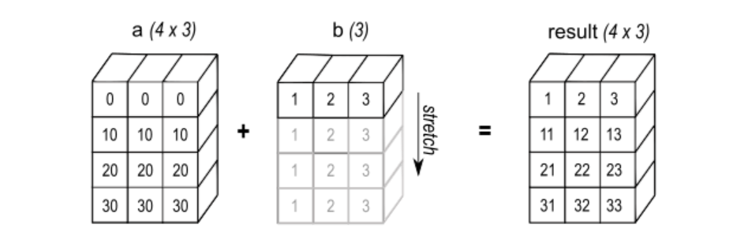

### Column-vector

Now, consider another pair:

$$\mathbf{M} = \begin{bmatrix}
1 & 2 & 3\\
4 & 5 & 6
\end{bmatrix}, \mathbf{b} = \begin{bmatrix}
1\\
2
\end{bmatrix}$$

In this case, we have:

$$\mathbf{M} + \mathbf{b} = \begin{bmatrix}
2 & 3 & 4\\
6 & 7 & 8
\end{bmatrix}$$

In `NumPy`:

```python
M = np.array([
    [1, 2, 3],
    [4, 5, 6]
])
b = np.array([1, 2]).reshape(2, 1)
M + b
```

```
array([[2, 3, 4],
       [6, 7, 8]])
```

## Advanced Indexing

NumPy has some advanced indexing features.

### Indexing using arrays

`NumPy` arrays themselves can be used as indices to retreive different parts of the array. For example:

$$\mathbf{x} = \begin{bmatrix}
-1 & 0 & 4 & 3 & 7 & 8 & 1 & 9
\end{bmatrix}$$

Let us say that we are interested in retreiving indices: `[1, 3, 6]`.

In `NumPy`:

```python
x = np.array([-1, 0, 4, 3, 7, 8, 1, 9])
x[np.array([1, 3, 6])]
```

```
array([0, 3, 1])
```

```python
x = np.array([-1, 0, 4, 3, 7, 8, 1, 9])
x[[1, 3, 6]]
```

```
array([0, 3, 1])
```

### Filtering particular values

Sometimes we are interested in those elements of the array that possess a particular property:

$$\mathbf{x} = \begin{bmatrix}
3 & 1 & 5 & -4 & -2 & 1 & 5
\end{bmatrix}$$

Let us try to extract all elements that are positive.

In `NumPy`:

```python
x = np.array([3, 1, 5, -4, -2, 1, 5])
x > 0
```

```
array([ True,  True,  True, False, False,  True,  True])
```

```python
x = np.array([3, 1, 5, -4, -2, 1, 5])
x[x > 0]
```

```
array([3, 1, 5, 1, 5])
```

### Filtering and follow-up

Let us try to implement the ReLU function.

$$\text{ReLU}(x) = \begin{cases}
x, & x \geqslant 0\\
0, & x < 0
\end{cases}$$

```python
def relu(x):
    return np.where(x > 0, x, 0)
relu(np.array([1, -2, 1, 3, -4, -3]))
```

```
array([1, 0, 1, 3, 0, 0])
```

## Operations along axes

Sometimes we may wish to do some operations on all the row-vectors of a matrix or all the column-vectors of the matrix. The idea of `axis` is important to understand how these operations can be done.

### Top-bottom

Top-bottom operations are done on row-vectors. For example, consider the matrix:

$$\mathbf{A} = \begin{bmatrix}
1 & 2 & 3 & 4\\
5 & 6 & 7 & 8
\end{bmatrix}$$

The sum of the row-vectors of the matrix is a vector:

$$\text{rsum}(\mathbf{A}) = \begin{bmatrix}
6 & 8 & 10 & 12
\end{bmatrix}$$

In `NumPy`:

```python
A = np.arange(1, 9).reshape(2, 4)
A.sum(axis = 0)
```

```
array([ 6,  8, 10, 12])
```

### Left-right

Left-right operations are done on column-vectors.

$$\mathbf{A} = \begin{bmatrix}
1 & 2 & 3 & 4\\
5 & 6 & 7 & 8
\end{bmatrix}$$

The sum of the column-vectors of the matrix is a vector:

$$\text{csum}(\mathbf{A}) = \begin{bmatrix}
10\\
26
\end{bmatrix}$$

In `NumPy`:

```python
A.sum(axis = 1)
```

```
array([10, 26])
```

### Sum, Mean, Variance, Norm

Some of the operations that can be done in this manner. Let us use the following matrix to demonstrate this:

$$\mathbf{M} = \begin{bmatrix}
1 & 2 & 3\\
4 & 5 & 6\\
7 & 8 & 9
\end{bmatrix}$$

Let us find the following quantities:

- sum of column-vectors
- mean of row-vectors
- variance of column-vectors

```python
M = np.arange(1, 10).reshape(3, 3)
M
```

```
array([[1, 2, 3],
       [4, 5, 6],
       [7, 8, 9]])
```

```python
# sum of column vectors
M.sum(axis = 1)
```

```
array([ 6, 15, 24])
```

```python
# mean of row vectors
M.mean(axis = 0)
```

```
array([4., 5., 6.])
```

```python
# variance of column vectors
M.var(axis = 1)
```

```
array([0.66666667, 0.66666667, 0.66666667])
```

## Stacking arrays

Sometimes, we would want to stack arrays. Consider the two matrices:

$$\mathbf{A} =
\begin{bmatrix}
1 & 2\\
3 & 4
\end{bmatrix},
\mathbf{B} =
\begin{bmatrix}
5 & 6\\
7 & 8
\end{bmatrix}$$

There are two ways to stack these two matrices:

- top-bottom
- left-right

### Top-bottom

We could stack the two matrices along the rows, $\mathbf{A}$ on top of $\mathbf{B}$:

$$\mathbf{C} =
\begin{bmatrix}
1 & 2\\
3 & 4\\
5 & 6\\
7 & 8
\end{bmatrix}$$

In `NumPy`:

```python
A = np.array([[1, 2], [3, 4]])
B = np.array([[5, 6], [7, 8]])
np.concatenate((A, B), axis = 0)
```

```
array([[1, 2],
       [3, 4],
       [5, 6],
       [7, 8]])
```

### Left-right

We could stack the two matrices along the columns, $\mathbf{A}$ to the left of $\mathbf{B}$:

$$\mathbf{C} =
\begin{bmatrix}
1 & 2 & 5 & 6\\
3 & 4 & 7 & 8\\
\end{bmatrix}$$

In `NumPy`:

```python
A = np.array([[1, 2], [3, 4]])
B = np.array([[5, 6], [7, 8]])
np.concatenate((A, B), axis = 1)
```

```
array([[1, 2, 5, 6],
       [3, 4, 7, 8]])
```

## Misc functions

Let us look at a few other functions that are quite useful:

- `max` and `argmax`
- `min` and `argmin`
- `sort` and `argsort`

```python
x = np.array([10, -3, 2, 15, 5])
x
```

```
array([10, -3,  2, 15,  5])
```

```python
# max, argmax
np.max(x), np.argmax(x)
```

```
(15, 3)
```

```python
# min, argmin
np.min(x), np.argmin(x)
```

```
(-3, 1)
```

```python
# sort, argsort
np.sort(x), np.argsort(x)
```

```
(array([-3,  2,  5, 10, 15]), array([1, 2, 4, 0, 3]))
```

These functions also work on arrays of dimension more than one. If we specify an axis, the maximum will be computed along that axis.

```python
M = np.array([
    [1, 3, 5],
    [3, -1, -4]
])
np.max(M, axis = 1)
```

```
array([5, 3])
```

A similar mechanism holds for `sort`:

```python
M = np.array([
    [1, 3, 5],
    [3, -1, -4],
    [5, -4, 10]
])
np.sort(M, axis = 0)
```

```
array([[ 1, -4, -4],
       [ 3, -1,  5],
       [ 5,  3, 10]])
```

## Comparing Arrays

To check if two arrays are equal element-wise, we use `np.array_equal`:

```python
x = np.array([1, 2, 3])
y = np.array([1, 2, 3])
np.array_equal(x, y)
```

```
True
```

```python
x = np.array([1, 2, 4])
y = np.array([1, 2, 3])
np.array_equal(x, y)
```

```
False
```

```python
x = np.array([1, 2, 4])
y = np.array([1, 2, 3])
np.array_equal(x, y)
```

```
False
```

Sometimes the arrays being compared may not be exactly equal because of finite precision used to represent real numbers. In such situation, we can use `np.allclose` and specify the tolerance we want.

```python
x = np.array([1.0001, 2.0001, 3.0001])
y = np.array([1, 2, 3])
np.allclose(x, y, rtol = 0, atol = 1e-2)
```

```
True
```

# Example

We will now look at an of an image dataset.

```python
import matplotlib.pyplot as plt
from keras.datasets import mnist
```

```python
train, test = mnist.load_data()
```

```
Downloading data from https://storage.googleapis.com/tensorflow/tf-keras-datasets/mnist.npz

11490434/11490434 ━━━━━━━━━━━━━━━━━━━━ 0s 0us/step
```

```python
X, y = train
```

```python
print(X.shape)
print(y.shape)
```

```
(60000, 28, 28)
(60000,)
```

Let us look at a sample image. It is of shape $28 \times 28$.

```python
img = X[y == 7][0]
img.shape
plt.imshow(img, cmap = 'gray')
```

[figure not shown]

This can be treated as a tabular dataset. To do this, we would have to reshape the data-matrix:

```python
print('Original shape', X.shape)
X = X.reshape(60000, -1).T
print('Final shape', X.shape)
```

```
Original shape (60000, 28, 28)
Final shape (784, 60000)
```

We can now treat this as a data-matrix of shape $d \times n$, where $d = 784$ and $n = 60,000$.